# Computational Linguistic Analysis of Online Media

## Background

This project is an analysis of news media using Python's industry-standard natural language programming libraries, including NLTK, Textacy, Scikit-Learn, MALLET, and others. By leveraging NLP paradigms, this project demonstrates the value of core computational linguistic concepts: scraping datasets from the web; pre-processing text as part of text sanitization; and examining corpora quantitatively through TF-IDF, PCA, LDA and other methods.

## Project focus

In the 21st century, the threat to and importance of journalism have never been greater. As such, the goal of this project is to study the language of various news outlets using natural language processing methods to determine if there are any discernible patterns as to how news is reported and what distinguishes sites from one another.

## Full Project

### Installation

```python
%pip install flex-text-table
%pip install gensim
%pip install gensim
%pip install matplotlib
%pip install matplotlib
%pip install nbconvert
%pip install newspaper3k
%pip install nltk
%pip install numpy
%pip install pandas
%pip install prettytable
%pip install scikit-learn
%pip install scipy
%pip install scipy
%pip install seaborn
%pip install spacy
%pip install textacy
%pip install textblob
%pip install textwrap3
```

### Import relavent packages

```python
# Import textacy and spacy
try:
    import textacy, spacy
    from spacy import displacy
    nlp = spacy.load('en_core_web_sm')
    nlp.max_length = 9999999
    eng = spacy.load('en_core_web_sm', disable=['parser'])  # Disable parser if not needed
    spacy.load('en_core_web_sm')
except:
    print("The following must be run in the command line: python -m spacy download en_core_web_sm")
```

```python
# Import NLTK
import nltk
nltk.download('popular')
nltk.download('nps_chat')
nltk.download('webtext')

from nltk import word_tokenize
from nltk.book import *
from nltk.corpus import names as PersonalNames, stopwords, wordnet as wn
from nltk.tokenize import RegexpTokenizer
import nltk.data
```

```
*** Introductory Examples for the NLTK Book ***
Loading text1, ..., text9 and sent1, ..., sent9
Type the name of the text or sentence to view it.
Type: 'texts()' or 'sents()' to list the materials.
text1: Moby Dick by Herman Melville 1851
text2: Sense and Sensibility by Jane Austen 1811
text3: The Book of Genesis
text4: Inaugural Address Corpus
text5: Chat Corpus
text6: Monty Python and the Holy Grail
text7: Wall Street Journal
text8: Personals Corpus
text9: The Man Who Was Thursday by G . K . Chesterton 1908
```

```python
# Other imports
from collections import Counter, defaultdict
from gensim import corpora, matutils, models, similarities
from gensim.matutils import corpus2dense
from gensim.models.wrappers import LdaMallet
from matplotlib import pyplot as plt
from prettytable import PrettyTable
from scipy.cluster.hierarchy import dendrogram, linkage
from scipy.spatial.distance import pdist, squareform
from sklearn.decomposition import PCA
from sklearn.naive_bayes import BernoulliNB
from textblob.classifiers import NaiveBayesClassifier

import glob
import math
import matplotlib.pyplot as plt
import newspaper # For getting text: newspaper.readthedocs.io/
import numpy as np
import nbconvert # For conf.json: github.com/jupyter/nbconvert/issues/1394#issuecomment-1193793050
import pandas as pd
import random
import re
import seaborn as sns
import textwrap
import time

# Visualization settings
%matplotlib inline
display(HTML("<style>.container { width:100% !important; }</style>"))
```

## Define database

The first step in approaching the analysis is to determine the news outlets to study. The sites chosen—Breitbart, CNN, Economist, Fox, Mother Jones, New York Times, Vox, Wall Street Journal, Yahoo—were based on two criteria: popularity and partisan leaning.

Popularity was gauged by online traffic. Two thirds of the media outlets chosen amass more than 100 million page views in one month, qualifying them to be among the [most 100 most read U.S. media publications](https://www.similarweb.com/blog/us-media-publications-ranking-april-2017), according to data analytics firm SimilarWeb. According to Amazon's Website Traffic, Statistics and Analytics service, the traffic of the sites’ home pages used in this report; ranked in order of popularity: Yahoo, CNN, New York Times, Fox, Wall Street Journal, Vox, Breitbart, Economist, Mother Jones.

To create a varied dataset, sources from across the political spectrum were selected. A [2014 Pew Research Survey](http://guides.lib.umich.edu/c.php?g=637508&p=4462444), analyzing political leanings of major news sources would arrange from ideologically liberal to ideologically conservative the chosen outlets as: New York Times, Economist, CNN, Yahoo, WSJ, Fox, Breitbart. Although the Pew Research study examined the audience of each outlet’s political leanings, the ideology of a publication’s readership is an adequate proxy for the ideology of the publication. A “political bias” guide published by the University of Michigan was used to supplement the metrics from the Pew Research Center, which generally categorized news sources into different political groups: Mother Jones as “far left,” New York Times as “towards the left,” Wall Street Journal as “centrist,” and Fox News as “towards the right.” Finally, Vox’s founder and former-Washington Post writer, Ezra Klein noted in a 2017 interview that “[Vox’s] audience data...leans a bit left.”

For each media outlet analyzed, a corpus was created by collecting articles from the outlet published each day for several weeks. During this period, once a day, dozens of articles hosted in the politics subsection of the online editions were retrieved and added to the corpus of that site.

So, to create the corpus:

1. Iterate over the politics section of each new site so as to exclude other non-indicative sections such as sports
2. Use the build() method of the Newspaper3k library—designed for article scraping and curation—to accumulate all of the articles at that URL
3. Write the result to a file stored on the researcher’s local machine

```python
# Selected media outlets
news_urls = [
 'http://www.breitbart.com/news/topic/politics/',
 'http://www.cnn.com/politics',
 'http://www.economist.com/topics/politics',
 'http://www.foxnews.com/politics',
 'http://www.motherjones.com/politics/',
 'http://www.nytimes.com/politics',
 'http://www.vox.com/policy-and-politics',
 'http://www.wsj.com/news/politics',
 'http://www.yahoo.com/news/politics/']

def saveall(date):
    for site in news_urls:
        siteName = str(site[site.index('www')+4:site.index('.com')])
        create_and_save(create_corpus(site), r"./files/" + siteName + "/" + date + '.txt')

def create_and_save(corpus, path):
    fh = open(path, "w+")
    fh.write(corpus)
    fh.close()

def create_corpus(site):
    corpus_text = ""
    corpus_raw = newspaper.build(site, language='en')
    for i in range(corpus_raw.size()):
        article = corpus_raw.articles[i]
        article.download()
        article.parse()
        corpus_text += article.text
    siteName = str(site[site.index('www.')+4:site.index('.com')])
    articleCount = str(corpus_raw.size())
    wordCount = str(len(corpus_text.split()))
    print (siteName + " has " + articleCount + " articles and " + wordCount + " words")
    return corpus_text

# Run once a day; output is what is captured that day
saveall(date='3_01_24')
```

```
breitbart has 10 articles and 3201 words
cnn has 5 articles and 3934 words
economist has 45 articles and 21167 words
foxnews has 204 articles and 68983 words
motherjones has 40 articles and 31923 words
nytimes has 129 articles and 84119 words
vox has 114 articles and 158841 words
wsj has 153 articles and 31576 words
yahoo has 162 articles and 73128 words
```

### Sanitize Dataset

Sanitizing the data is a crucial step to ensure that the text data is in a suitable format for analysis. The following preprocessing steps were taken: tokenization, punctuation removal, stopwords removal, names of people removal, case unification, lemmatization.

- Tokenization: Involves breaking the text into individual words or tokens. This step is essential because most NLP tasks operate on a word-by-word basis, and tokenization provides the basic units for analysis.
- Remove Punctuation: Punctuation marks often do not carry significant meaning in many NLP tasks. Removing punctuation helps reduce noise in the data and makes it easier to analyze the text.
- Remove Stopwords: Stopwords are common words that occur frequently in a language but often do not carry much semantic meaning (e.g., "the", "is", "and"). Removing stopwords helps reduce the dimensionality of the data and focuses analysis on words that are more informative.
- Remove Names of People: In some NLP tasks, such as sentiment analysis or topic modeling, the presence of specific named entities like people's names may not be relevant and could introduce bias or noise. Removing names of people helps generalize the text and focus on the underlying themes or sentiments.
- Unify Case: Standardizing the case of words (e.g., converting all words to lowercase) helps ensure consistency in the data and avoids treating the same word differently based on its capitalization. For example, "Apple" and "apple" should be considered the same word in many NLP tasks.
- Lemmatize: Lemmatization involves reducing words to their base or canonical form (i.e., their lemma). This step helps normalize different forms of words to their common root, which reduces the complexity of the data and improves the accuracy of analysis. For example, "running" and "ran" would both be lemmatized to "run".

By performing these preprocessing steps, the text data is transformed into a cleaner, more standardized format that is better suited for various NLP tasks such as text classification, sentiment analysis, named entity recognition, and more.

### Analyze dataset

The following attributes were determined to be so weakly correlated that their relationship approaches randomness: average sentence length and popularity, average word length and bias, content fraction and popularity, lexical diversity and popularity. One reasonable way to explain why there seems to be no strong correlation in content fraction, for example, is that a measurement that makes no distinction beyond function and content words is too coarse of a tool for a meaningful difference to emerge. This is supported by the fact that all corpuses have a very similar trend in their relative frequency of each part of speech and readability scores.

Yet there is a notable correlation in three areas; in increasing strength: average sentence length increases with bias, average word length decreases with popularity, and punctuation percent decreases with popularity. The combination of the latter two results strongly suggest that audiences are more attracted to less technical, easier-to-digest articles. Whether, over time, outlets have modified their content to cater to their readers’ bite-sized preferences and byte-sized, on-the-go readership habits would be an interesting area of further research.

[figure not shown]

```python
def main():
    getAndPrepareFiles(r"./files/*/*.txt")
    sanitizeAndAnalyze()
    Corpus.displayResults()

def getAndPrepareFiles(path):
    files = glob.glob(path)
    i=0
    while i < (len(files)):
        Corpus("", name=getNameFromPath(files[i])) # Create a new Corpus object
        j = i
        while j < len(files) and getNameFromPath(files[i]) == getNameFromPath(files[j]):
            print (files[j])
            Corpus.database[len(Corpus.database)-1].addToCorpus(open(files[j], 'r').read())
            j+=1
        corpusName = Corpus.database[len(Corpus.database)-1].name
        characterCount = str(len(Corpus.database[len(Corpus.database)-1].corpus))
        print (corpusName + " created with initial, unedited " + characterCount + " characters")
        i=j

# Return media source aka NAME based on 'base_path/files/NAME/DATE.txt' file structure
def getNameFromPath(path):
    return path[path.index('files')+6:path.index('.txt')-8]

def sanitizeAndAnalyze():
    for corpus in Corpus.database:
            corpus.readability()
            corpus.avgLength()
            corpus.tokenize()
            corpus.removePunctuation()
            corpus.removeStopwords()
            corpus.mostCommonEntities(scope=5)
            corpus.removeNamesOfPeople()
            corpus.removeRareWords()
            corpus.unifyCase()
            corpus.tenseAnalysis()
            corpus.lemma()
            corpus.wordAnalysis()
            corpus.corpusAnalysis()
            corpus.frequency(scope=5)
            corpus.lexicalDiversity(chunk_size=2000)

main()
```

### Class and methods for basic sanitization and analysis

To keep track of all variables, each corpus was instantiated as a Corpus object, whose instance variables include the corpus’ name, text, and a variable for each of the other measurements listed in the analysis step. Additionally, when a new Corpus object is instantiated, it is added to a list named database; so, Corpus.database could easily either be indexed into or iterated over throughout the program, which aids in both testing and code simplicity. Further, each step during the sanitizing and analyzing step has its own dedicated function, each of which need to be called on a Corpus object. It should also be noted that some methods take either a scope or a chunk_size variable; these variables were set to 5 and 2000, respectively. Also, the third and last function called in main(), displayResults(), produces all of the quantitative output.

```
+-------------+---------------------+
|    Source   | avg_sentence_length |
+-------------+---------------------+
|  economist  |        21.927       |
|   nytimes   |        22.053       |
|   foxnews   |        22.527       |
|     cnn     |        22.584       |
| motherjones |        23.607       |
|     vox     |        24.106       |
|     wsj     |        24.212       |
|    yahoo    |        24.312       |
|  breitbart  |        25.505       |
+-------------+---------------------+
+-------------+-----------------+
|    Source   | avg_word_length |
+-------------+-----------------+
|    yahoo    |       4.74      |
|     vox     |      4.775      |
|   nytimes   |      4.786      |
|     cnn     |      4.795      |
|   foxnews   |      4.808      |
|  breitbart  |       4.88      |
| motherjones |      4.907      |
|     wsj     |      4.985      |
|  economist  |      5.094      |
+-------------+-----------------+
+-------------+------------------+
|    Source   | content_fraction |
+-------------+------------------+
|     vox     |       0.57       |
|     cnn     |      0.599       |
| motherjones |      0.603       |
|   nytimes   |      0.605       |
|  breitbart  |      0.617       |
|  economist  |      0.621       |
|   foxnews   |      0.621       |
|    yahoo    |      0.629       |
|     wsj     |      0.647       |
+-------------+------------------+
+-------------+-------------------+
```

[output cut: 36 more lines]

```
|   nytimes   | [11, 199, 178, 61, 119, 5] |
+-------------+----------------------------+
+-------------+-------------------------------------------------------------------+
|    Source   |                           word_analysis                           |
+-------------+-------------------------------------------------------------------+
|     vox     |        ['Cosby', 'Zuckerberg', 'one', 'Trump', 'Facebook']        |
|     cnn     | ['Democratic', 'Trump', 'Republican', 'Republicans', 'Democrats'] |
|  breitbart  |          ['Monday', 'Russia', 'Syrian', 'Trump', 'Syria']         |
|     wsj     |          ['Syria', 'Donald Trump', 'one', 'first', 'U S']         |
|  economist  |         ['Trump', 'Upgrade', 'American', 'America', 'one']        |
|   foxnews   |              ['first', 'FBI', 'U S', 'one', 'Trump']              |
| motherjones |          ['first', 'Pruitt', 'Subscribe', 'one', 'Trump']         |
|    yahoo    |             ['one', 'U S', 'Cohen', 'Syria', 'Trump']             |
|   nytimes   |     ['two', 'Syria', 'one', 'Trump', 'Advertisement Continue']    |
+-------------+-------------------------------------------------------------------+
```

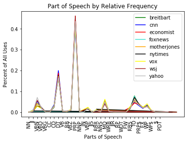

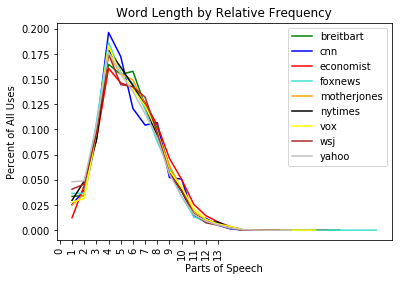

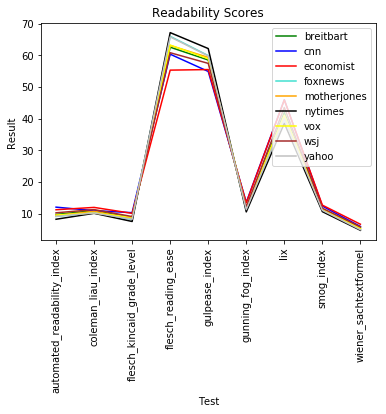

```python
class Corpus:
    database = []
    tag_fd_dict = {}
    word_length_dict = {}
    readability_dict = {}

    avg_sentence_length = None
    avg_word_length = None
    punctuation_percent = None
    content_fraction = None
    tense_analysis = []
    word_analysis = []
    lexical_diversity = None


    def __init__(self, corpus, name):
        self.corpus = corpus
        self.name = name
        self.avg_sentence_length = None
        self.avg_word_length = None
        self.punctuation_percent = None
        self.content_fraction = None
        self.tense_analysis = []
        self.word_analysis = []
        self.lexical_diversity = None
        self.database.append(self)

    def addToCorpus(self, text):
        self.corpus += text
        if len(self.corpus) > 90000:
            #900000 limit because of Python 2-Spacy size limit
            self.corpus = self.corpus[:90000]

    def readability(self):
        doc = textacy.Doc(str(self.corpus), lang='en')
        ts = textacy.TextStats(doc)
        self.readability_dict[self.name] = ts.readability_stats

    def avgLength(self):
         #Adapted from: https://mailman.uib.no/public/corpora/2007-October/005426.html
        tokenizer = nltk.data.load('tokenizers/punkt/english.pickle')
        num_sentences = len(tokenizer.tokenize(self.corpus))
        total_characters = len(re.findall('[a-zA-Z]',self.corpus))
        total_words = len(self.corpus.split())
        self.avg_sentence_length = round(float(total_words)/num_sentences, 3)
        self.avg_word_length =  round(float(total_characters)/total_words, 3)

    def tokenize(self):
        self.corpus = word_tokenize(self.corpus)

    def removePunctuation(self):
        nopunct = RegexpTokenizer(r'\w+')
        total_characters = 0
        for w in self.corpus:
            total_characters += len(w)
        self.corpus = nopunct.tokenize(str(self.corpus))
        punctuation = 0
        for w in self.corpus:
            punctuation += len(w)
        self.punctuation_percent = round((punctuation / total_characters), 3)

    # Adapted from: http://www.nltk.org/book/ch02.html
    def removeStopwords(self):
        stopwords1 = nltk.corpus.stopwords.words('english')
        content = [w for w in self.corpus if w not in stopwords1 and w.upper() not in stopwords1]
        self.content_fraction = round(float(len(content)) / len(self.corpus), 3)
        self.corpus = [w for w in self.corpus if w not in stopwords1 and w.upper() not in stopwords1]

    def mostCommonEntities(self, scope):
        doc = textacy.Doc(str(" ".join(self.corpus)), lang='en')
        fdist = FreqDist(textacy.extract.named_entities(doc, drop_determiners=True))
        fdist2 = []
        for key, value in fdist.items():
            fdist2.append(str(key))
        fdist = FreqDist(fdist2)
        fdist.plot(scope, title = str(self.name + "\'s Most Common " + str(scope) + " Entities"))
        for item in list(fdist.most_common(scope)):
            self.word_analysis.append((str(item[0])))
        # Visualize frequency of word in corpus
        nltk.Text(self.corpus).dispersion_plot(self.word_analysis)

    def removeNamesOfPeople(self):
        PN = PersonalNames.words()
        self.content = [w for w in self.corpus if w not in PN]

    def unifyCase(self, case = "L"):
        if case == "L":
            self.corpus = [w.lower() for w in self.corpus]
        elif case == "U":
            self.corpus = [w.upper() for w in self.corpus]

    # Adapted from: http://www.nltk.org/book/ch02.html
    def tenseAnalysis(self):
        fdist = FreqDist(self.corpus)
        modals = ['can', 'could', 'may', 'might', 'must', 'will']
        for m in modals:
            self.tense_analysis.append(fdist[m])

    def lemma(self):
        wnl = nltk.WordNetLemmatizer()
        self.corpus = [wnl.lemmatize(t) for t in self.corpus]

    def removeRareWords(self):
        freq_dist = nltk.FreqDist(self.corpus)
        rarewords = [ k for (k,v) in freq_dist.items() if v == 1]
        self.corpus = [w for w in self.corpus if w not in rarewords]

    def wordAnalysis(self, keywords = None):
        if keywords == None:
            keywords = self.word_analysis
        print ("Common contexts of \'" + (", ").join(keywords) + "\' in " + self.name)
        for word in keywords:
            print ( word + ": ", end = '')
            nltk.Text(self.corpus).common_contexts([str(word)])

        print("WORD \t\t\t Used In Similar Context As" )
        for word in keywords:
            print(str(word) + ": ", end = '')
            nltk.Text(self.corpus).similar(word)

    def corpusAnalysis(self):
        print (self.name + "'s Collocations aka Words Commonly Used Together: ")
        nltk.Text(self.corpus).collocations()
        tag_fd = nltk.FreqDist(tag for (word, tag) in nltk.pos_tag(self.corpus))
        sum = 0
        for tag in tag_fd:
            sum += tag_fd[tag]
        for tag in tag_fd:
            tag_fd[tag] = tag_fd[tag] / sum
        self.tag_fd_dict[self.name] = tag_fd

    def lexicalDiversity(self, chunk_size):
        if len(self.corpus)!=0:
            total_length= len(self.corpus)
            unique = 0
            for i in range(0, len(self.corpus), chunk_size):
                unique += len(set(self.corpus[i:i+chunk_size]))
            self.lexical_diversity = round(unique / total_length, 3)

    def frequency(self, scope):
        fdist = FreqDist(self.corpus)
        fdist.plot(scope, title = str(self.name + "'s Most Common " + str(scope) + " Words"))
        fdist = FreqDist(len(w) for w in self.corpus)
        sum = 0
        for tag in fdist:
            sum += fdist[tag]
        for tag in fdist:
            fdist[tag] = fdist[tag] / sum
        self.word_length_dict[self.name] = fdist

    # Adapted from: https://spacy.io/usage/vectors-similarity
    def vectorAnalysis_unchunked():
        first_row = ['Word Vectors: Unchunked']
        for corpus in Corpus.database:
            first_row.append(corpus.name[:3])
        table = PrettyTable(first_row)
        i = 0
        while i < len(Corpus.database):
            doc1 = nlp(str(" ".join(Corpus.database[i].corpus)))
            row = [Corpus.database[i].name]
            row += [""]*(i)
            j = i
            while j < len(Corpus.database):
                doc2 = nlp(str(" ".join(Corpus.database[j].corpus)))
                row.append(round(doc1.similarity(doc2), 3))
                j += 1
            table.add_row(row)
            i += 1
        print (table.get_string())

    def vectorAnalysis_chunk(chunk_size):
        first_row = ['Word Vectors: ' + str(chunk_size) + "-word chunks"]
        for corpus in Corpus.database:
            first_row.append(corpus.name[:3])
        table = PrettyTable(first_row)
        i = 0
        while i < len(Corpus.database):
            row = [Corpus.database[i].name]
            row += [""]*(i)
            j = i
            while j < len(Corpus.database):
                vec = 0
                for k in range(0, len(Corpus.database[i].corpus), chunk_size):
                    doc1 = nlp(str(" ".join(Corpus.database[i].corpus[k:k+chunk_size])))
                    for l in range(0, len(Corpus.database[j].corpus), chunk_size):
                        doc2 = nlp(str(" ".join(Corpus.database[j].corpus[l:l+chunk_size])))
                        sim = doc1.similarity(doc2)
                        vec += (sim) / (np.ceil(len(Corpus.database[i].corpus)/chunk_size)*np.ceil(len(Corpus.database[j].corpus)/chunk_size))
                row.append(round(vec, 2))
                j += 1
            table.add_row(row)
            i += 1
        print (table.get_string())


    def displayResults(chunk_size=2000):
        for datapoint in dir(Corpus):
            if not datapoint.startswith('__') and not callable(getattr(Corpus,datapoint)) and datapoint!='database' and datapoint!='tag_fd_dict' and datapoint!='word_length_dict' and datapoint!='readability_dict':
                table = PrettyTable(['Source', datapoint])
                for corpus in Corpus.database:
                    table.add_row([corpus.name, getattr(corpus, datapoint)])
                print (table.get_string(sortby=datapoint))


        colors = ["green", "blue", "red", "turquoise", 'orange', 'black', 'yellow', 'brown', 'silver']
        for i, label in enumerate(Corpus.tag_fd_dict):
            lists = sorted(Corpus.tag_fd_dict[label].items()) # sorted by key, return a list of tuples
            x, y = zip(*lists) # unpack a list of pairs into two tuples
            color = colors[i]
            plt1.plot(x, y, color=color, label=label)
        plt1.xticks(np.arange(0, len(Corpus.tag_fd_dict['cnn']), 1), Corpus.tag_fd_dict['cnn'].keys(), rotation=90)
        plt1.title('Part of Speech by Relative Frequency')
        plt1.xlabel("Parts of Speech")
        plt1.ylabel("Percent of All Uses")
        plt1.legend(loc="upper right")
        plt1.show()


        for i, label in enumerate(Corpus.word_length_dict):
            lists = sorted(Corpus.word_length_dict[label].items()) # Sorted by key, return a list of tuples
            x, y = zip(*lists) # Unpack a list of pairs into two tuples
            color = colors[i]
            plt1.plot(x, y, color=color, label=label)
        plt1.xticks(np.arange(0, 14, 1), rotation=90)
        plt1.title('Word Length by Relative Frequency')
        plt1.xlabel("Parts of Speech")
        plt1.ylabel("Percent of All Uses")
        plt1.legend(loc="upper right")
        plt1.show()

        # Adapted from:
        # chartbeat-labs.github.io/textacy/getting_started/quickstart.html#analyze-a-doc
        for i, label in enumerate(Corpus.readability_dict):
            lists = sorted(Corpus.readability_dict[label].items()) # Sorted by key, return a list of tuples
            x, y = zip(*lists) # Unpack a list of pairs into two tuples
            color = colors[i]
            plt1.plot(x, y, color=color, label=label)
        plt1.xticks(np.arange(0, 9, 1), rotation=90)
        plt1.title('Readability Scores')
        plt1.xlabel("Test")
        plt1.ylabel("Result")
        plt1.legend(loc="upper right")
        plt1.show()
```

```python
# Naive method with long execution time
Corpus.vectorAnalysis_chunk(10000)
```

```
+---------------------------------+------+------+------+------+------+------+------+------+------+
| Word Vectors: 10000-word chunks | bre  | cnn  | eco  | fox  | mot  | nyt  | vox  | wsj  | yah  |
+---------------------------------+------+------+------+------+------+------+------+------+------+
|            breitbart            | 0.97 | 0.98 | 0.98 | 0.98 | 0.98 | 0.98 | 0.97 | 0.98 | 0.98 |
|               cnn               |      | 1.0  | 0.99 | 0.99 | 0.99 | 0.99 | 0.98 | 0.99 | 0.99 |
|            economist            |      |      | 1.0  | 0.99 | 0.99 | 0.99 | 0.98 | 0.99 | 0.98 |
|             foxnews             |      |      |      | 1.0  | 1.0  | 1.0  | 0.99 | 0.99 | 0.99 |
|           motherjones           |      |      |      |      | 1.0  | 1.0  | 0.99 | 0.99 | 0.99 |
|             nytimes             |      |      |      |      |      | 1.0  | 0.99 | 0.99 | 0.99 |
|               vox               |      |      |      |      |      |      | 0.99 | 0.98 | 0.98 |
|               wsj               |      |      |      |      |      |      |      | 1.0  | 0.99 |
|              yahoo              |      |      |      |      |      |      |      |      | 0.99 |
+---------------------------------+------+------+------+------+------+------+------+------+------+
```

### Advanced analysis

#### Selected Results:

```
breitbart created with initial, unedited 90000 characters
cnn created with initial, unedited 90000 characters
economist created with initial, unedited 90000 characters
foxnews created with initial, unedited 90000 characters
motherjones created with initial, unedited 90000 characters
nytimes created with initial, unedited 90000 characters
vox created with initial, unedited 90000 characters
wsj created with initial, unedited 90000 characters
yahoo created with initial, unedited 90000 characters
```

```
┌───┬─────────────┬───────┬───────┬───────┬───────┬───────┬───────┬───────┬───────┬───────┬───────┬───────┬───────┬───────┬───────┬───────┬───────┬┐
│   │             │     0 │     1 │     2 │     3 │     4 │     5 │     6 │     7 │     8 │     9 │    10 │    11 │    12 │    13 │    14 │    15 ││
├───┼─────────────┼───────┼───────┼───────┼───────┼───────┼───────┼───────┼───────┼───────┼───────┼───────┼───────┼───────┼───────┼───────┼───────┼┤
│ 0 │ breitbart   │       │       │       │       │       │       │       │       │       │       │       │       │       │       │       │ 1.00  ││
├───┼─────────────┼───────┼───────┼───────┼───────┼───────┼───────┼───────┼───────┼───────┼───────┼───────┼───────┼───────┼───────┼───────┼───────┼┤
│ 1 │ cnn         │       │       │       │       │       │       │       │       │       │       │       │       │       │       │       │ 1.00  ││
├───┼─────────────┼───────┼───────┼───────┼───────┼───────┼───────┼───────┼───────┼───────┼───────┼───────┼───────┼───────┼───────┼───────┼───────┼┤
│ 2 │ economist   │       │       │       │       │       │       │       │       │       │       │       │       │       │       │       │ 1.00  ││
├───┼─────────────┼───────┼───────┼───────┼───────┼───────┼───────┼───────┼───────┼───────┼───────┼───────┼───────┼───────┼───────┼───────┼───────┼┤
│ 3 │ foxnews     │       │       │       │       │       │       │       │ 0.11  │       │       │       │       │       │       │       │ 0.89  ││
├───┼─────────────┼───────┼───────┼───────┼───────┼───────┼───────┼───────┼───────┼───────┼───────┼───────┼───────┼───────┼───────┼───────┼───────┼┤
│ 4 │ motherjones │       │       │       │       │       │       │       │ 1.00  │       │       │       │       │       │       │       │       ││
├───┼─────────────┼───────┼───────┼───────┼───────┼───────┼───────┼───────┼───────┼───────┼───────┼───────┼───────┼───────┼───────┼───────┼───────┼┤
│ 5 │ nytimes     │       │       │       │       │       │       │       │ 0.07  │       │       │       │       │       │       │       │ 0.93  ││
├───┼─────────────┼───────┼───────┼───────┼───────┼───────┼───────┼───────┼───────┼───────┼───────┼───────┼───────┼───────┼───────┼───────┼───────┼┤
│ 6 │ vox         │       │       │       │       │       │       │       │ 0.93  │       │       │       │       │       │       │       │ 0.07  ││
├───┼─────────────┼───────┼───────┼───────┼───────┼───────┼───────┼───────┼───────┼───────┼───────┼───────┼───────┼───────┼───────┼───────┼───────┼┤
│ 7 │ wsj         │       │       │       │       │       │       │       │       │       │       │       │       │       │       │       │ 1.00  ││
├───┼─────────────┼───────┼───────┼───────┼───────┼───────┼───────┼───────┼───────┼───────┼───────┼───────┼───────┼───────┼───────┼───────┼───────┼┤
│ 8 │ yahoo       │       │       │       │       │       │       │       │ 0.92  │       │       │       │       │       │       │       │ 0.08  ││
└───┴─────────────┴───────┴───────┴───────┴───────┴───────┴───────┴───────┴───────┴───────┴───────┴───────┴───────┴───────┴───────┴───────┴───────┴┘
11733 is the length of the gensim_dictionary
9 is the length of the gensim_corpus
9 is the length of the gensim_lda_corpus

Topic0
	 0.58 foxnews

	mueller 44; pompeo 44; fox 31; rosenstein 28; ryan 25; paul 22; syria 21;
	attorney 20; sanctuary 19; trade 18; amendment 18; stockman 16; council 15;
	booker 15; gop 14; rips 13; raid 12; robert 12; balanced 12; ingraham 12; todd
	12; dana 11; senate 11; speaker 11; tax 11; tucker 11; fbi 11; listen 11;
	albright 11; 12 10; watch 10; brown 10; conservative 10; lawsuit 10; pelosi 10;
	clip 10; gay 10; audio 10; carlson 10; chairman 9; justice 9; congressman 9;
	chris 9; kudlow 9; tpp 9; immigration 8; sex 8; budget 8; dershowitz 8; digenova
	8

Topic1
	 0.52 motherjones

```

[output cut: 128 more lines]

```
	clinton 14; 2014 13

Topic15
	 0.50 nytimes

	mr 135; perrotta 40; _ 36; story 36; pruitt 30; main 24; advertisement 22; art
	22; photo 22; pierre 17; newsletter 16; nuclear 15; ryan 15; times 15;
	republicans 14; agency 13; bear 13; book 13; mulvaney 13; painting 13; bureau
	12; drug 12; energy 12; naloxone 12; pinch 11; pharmacies 11; father 10; email
	10; goldberg 10; individualism 10; list 9; pharmacy 9; prescription 9; address
	8; box 8; enter 8; error 8; nation 8; night 8; occurred 8; program 8; jersey 8;
	spending 8; products 8; subscribe 8; verify 8; invalid 8; newsletters 8;
	chmielewski 8; clicking 8

Topic16
```

```
	 0.21 economist
	 0.12 nytimes
	 0.15 wsj

	tax 32; senate 30; trade 28; business 28; ms 27; main 26; economy 25; health 22;
	single 22; hard 21; senior 21; energy 20; politicians 20; spending 20; half 19;
	free 18; bank 18; economic 17; private 16; small 16; measures 15; school 15;
	mexico 15; boss 14; building 14; cost 14; debt 14; recently 14; 8 13; children
	13; failed 13; rates 13; rest 13; short 13; sites 13; owner 13; politics 13; buy
	13; era 12; ground 12; independent 12; directly 12; exchange 12; worker 12;
	earlier 11; european 11; expected 11; income 11; named 11; popular 11

Topic19
	 0.46 breitbart

	_ 85; snow 45; storm 34; sunday 27; south 21; inches 20; minneapolis 20; heavy
	19; league 19; centimeters 18; wisconsin 18; haley 17; par 17; census 15; game
	15; turtle 15; winds 15; flights 14; macron 14; minnesota 14; alleged 13; cosby
	13; title 13; town 13; airport 12; blizzard 12; champions 12; dakota 12;
	nebraska 12; weather 12; conditions 11; expected 11; foreign 11; louisiana 11;
	rain 11; constand 10; green 10; guardiola 10; kim 9; percent 9; premier 9;
	canceled 8; central 8; freezing 8; illegal 8; joint 8; kodaira 8; legally 8;
	mckenzie 8; river 8
lda_matrix.shape:(20, 9)
lda_matrix.shape: (9, 20)
9is the length of results
explained_variance_ratio_:[ 0.19944033  0.17322963]
distances.shape (36,)
linkage_matrix.shape (8, 4)
NAIVE BAYES CLASSIFIER
accuracy 1.0
Most Informative Features
             contains(U) = False          progre : conser =      1.7 : 1.0
     contains(organized) = False          progre : conser =      1.7 : 1.0
       contains(dollars) = False          progre : conser =      1.7 : 1.0
           contains(way) = True           conser : progre =      1.7 : 1.0
        contains(Borger) = False          conser : progre =      1.7 : 1.0
       contains(regions) = False          progre : conser =      1.7 : 1.0
       contains(unclear) = False          conser : progre =      1.7 : 1.0
      contains(speaking) = False          progre : conser =      1.7 : 1.0
```

[output cut: 30 more lines]

```
traditional          conservative : progressive 	 3.0 : 1.0
tools                conservative : progressive 	 3.0 : 1.0
three                progressive : conservative 	 3.0 : 1.0
threat               progressive : conservative 	 3.0 : 1.0
thought              progressive : conservative 	 3.0 : 1.0
telling              progressive : conservative 	 3.0 : 1.0
support              progressive : conservative 	 3.0 : 1.0
stay                 progressive : conservative 	 3.0 : 1.0
statement            progressive : conservative 	 3.0 : 1.0
start                progressive : conservative 	 3.0 : 1.0
risk                 progressive : conservative 	 3.0 : 1.0
reported             progressive : conservative 	 3.0 : 1.0
questions            progressive : conservative 	 3.0 : 1.0
protected            progressive : conservative 	 3.0 : 1.0
Total execution:  0.6514139175415039  seconds
```

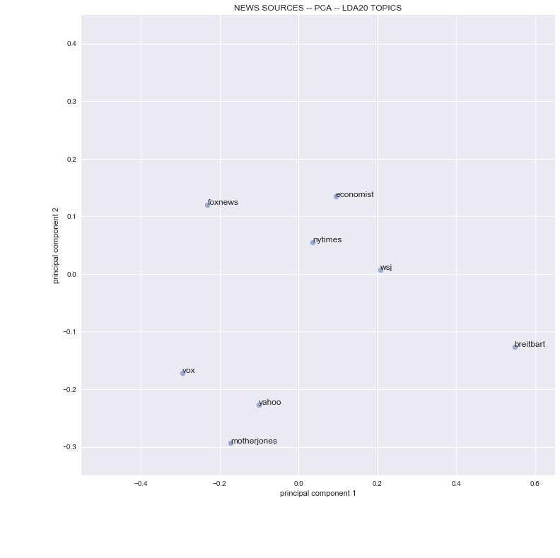

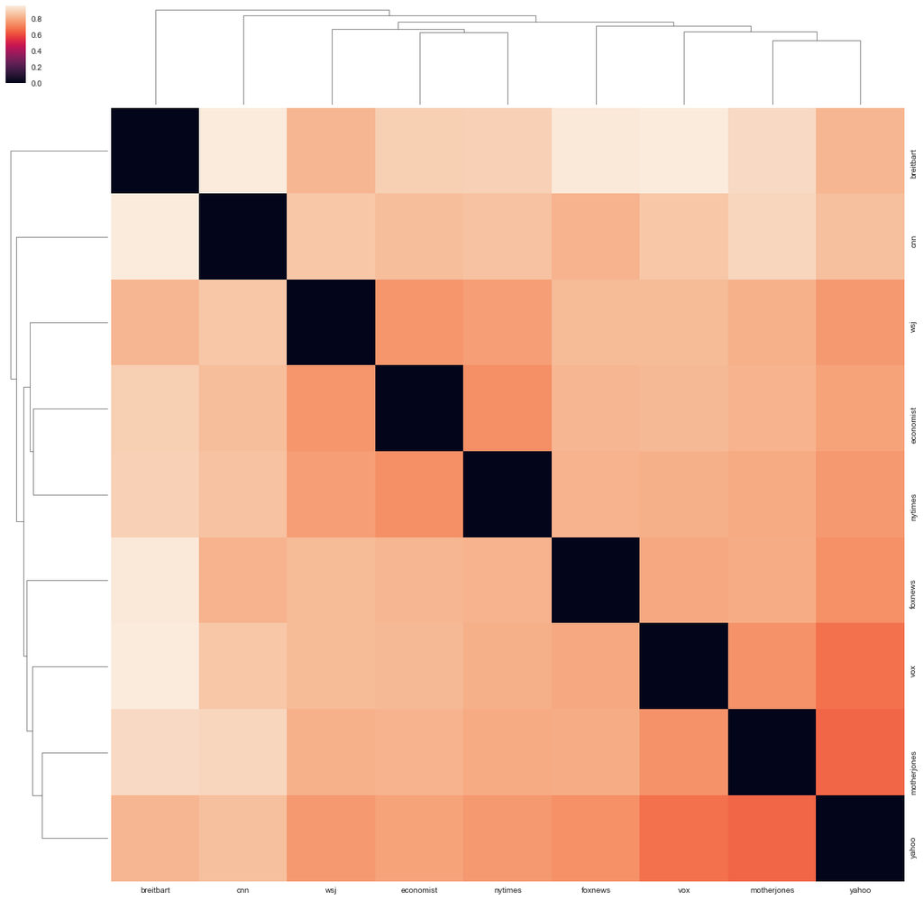

```python
def advancedAnalysis():
    getAndPrepareFiles(r"./files/*/*.txt")
    for corpus in Corpus.database:
            corpus.tokenize()
            simplify_text(corpus, scope=200)
            pos_text(corpus, scope=20)
            corpus.removePunctuation()
    corpus = keyterms()
    topics(corpus)
    res = tf_idf()
    res = pca(res[0], res[1])
    linkage_matrix(res)
    main_classify()
advancedAnalysis()
```

```python
# Display only the main content of each sentence using Textacy's part of speech-tagging capabilities
def simplify_text(corpus, scope):
    print (corpus.name + ': '),
    pdoc = nlp(str((' '.join(corpus.corpus))))
    all_noun_chunks = []
    for s in pdoc.sents:
        last_punct = ''
        for t in s:
            if t.pos_ == 'PUNCT' and t.text not in [u'—', u'”', '(', ')', u'“']:
                last_punct = t.text.replace(u'—', '')
        for c in s.noun_chunks:
            is_just_pronoun = False
            if len(c) == 1:
                for t in c:
                    if t.pos_ == 'PRON':
                        is_just_pronoun = True
            if is_just_pronoun == False:
                all_noun_chunks.append((c.text[0].upper() + c.text[1:] + last_punct).replace(u'“', ''))
    if len(all_noun_chunks) > 0:
        print ('\n'.join(textwrap.wrap(' '.join(all_noun_chunks), 70))[:scope] + '\n')
```

```python
# Present a visual sentence dependency using displaCy
def pos_text(corpus, scope):
    doc = nlp(str((' '.join(corpus.corpus)))[:scope])
    for s in doc.sents:
        s_doc = nlp(str(s))
        displacy.render(s_doc, jupyter=True, style='dep')
```

```python
# Determine the top words in each corpus using textacy's .keyterms functionality
def info(corpus):
    print (str(corpus.n_docs) + ' docs in corpus')
    print (str(corpus.n_sents) + ' sentences in corpus')
    print (str(corpus.n_tokens) + ' tokens in corpus')

def keyterms():
    corpus_input = []
    for corpus in Corpus.database:
        source = corpus.name
        raw_text = corpus.corpus
        selected_tokens = []
        doc = nlp(str(raw_text))
        for t in doc:
            if t.is_stop == False and t.is_punct == False and t.is_space == False:
                if t.lemma_ != '-PRON-':
                    selected_tokens.append(t.lemma_)
        corpus_input.append({
                       'source': source,
                       'raw_text': raw_text,
                       'selected_text': ' '.join(selected_tokens)})

    corpus = textacy.Corpus(
                u'en',
                texts = [str(i['selected_text']) for i in corpus_input],
                metadatas = [{'source': i['source']} for i in corpus_input])
    info(corpus)
    for doc in corpus:
        print ('\n' + doc.metadata['source'] + '\n')
        top_words = []
        for w in textacy.keyterms.textrank(doc, n_keyterms=20):
            top_words.append(w[0])
        print ('\n'.join(textwrap.wrap(', '.join(top_words), 80)))
    return corpus
```

```python
# Determine document-topic percentages (which topics make up what percentage of each document) using Textacy's topic modelling
def make_printable(topic_pcts):
    printable_pcts = []
    for pct in topic_pcts:
        formatted_pct = '%.2f' % pct
        if formatted_pct == '0.00':
            formatted_pct = '    '
        printable_pcts.append(formatted_pct)
    return printable_pcts

def topics(corpus):
    vectorizer = textacy.Vectorizer(tf_type='linear', apply_idf=False, apply_dl=False,  min_df=2, max_df=26)
    doc_term_matrix = vectorizer.fit_transform((doc.to_terms_list(ngrams=1, named_entities=True, as_strings=True)
                                                   for doc in corpus))
    model = textacy.TopicModel('lda', n_topics=20)
    model.fit(doc_term_matrix)
    doc_topic_matrix = model.transform(doc_term_matrix)

    topic_headings = []
    for a in range(len(doc_topic_matrix[0])):
        topic_headings.append(str(a).rjust(5))
    results =[['', ''] + topic_headings]
    for a in range(len(doc_topic_matrix)):
        results.append([a, corpus[a].metadata['source']] + make_printable(doc_topic_matrix[a]))
    print (tabletext.to_text(results))
```

```python
# Determine the most common words in each corpus
# based on the inter-document frequencies using Gensim's latent Dirichlet allocation (LDA) modeling
def process_text(text, document_frequencies=None, low_df=None, high_df=None):
    tokens = []
    doc = nlp((' '.join(text)))
    if document_frequencies==None:
        for token in doc:
            if token.pos_ not in ['SPACE', 'PUNCT'] and \
                token.tag_ not in ['PRP', 'PRP$'] and \
                token.is_stop == False and token.lemma_ not in ['\'s']:
                tokens.append(token.lemma_)
    else:
        for token in doc:
            if token.pos_ not in ['SPACE', 'PUNCT'] and \
                token.tag_ not in ['PRP', 'PRP$'] and \
                token.is_stop == False and token.lemma_ not in ['\'s'] and \
                document_frequencies[token.lemma_] > low_df and \
                document_frequencies[token.lemma_] < high_df:
                tokens.append(token.text.lower())
    return tokens

def tf_idf():
    tokenized_corpus = [process_text(corpus.corpus) for corpus in Corpus.database]
    gensim_dictionary = corpora.Dictionary(tokenized_corpus)
    gensim_corpus = [gensim_dictionary.doc2bow(text) for text in tokenized_corpus]
    tfidf_model = models.TfidfModel(gensim_corpus)
    document_frequencies = dict([(gensim_dictionary[word], (float(document_count) / len(tokenized_corpus)))
                                 for word, document_count in tfidf_model.dfs.items()])
    tokenized_corpus = [process_text(corpus.corpus, document_frequencies, .05, .95) for corpus in Corpus.database]
    N_TOPICS = 20
    gensim_dictionary = corpora.Dictionary(tokenized_corpus)
    gensim_corpus = [gensim_dictionary.doc2bow(text) for text in tokenized_corpus]
    print (str(len(gensim_dictionary)) + " is the length of the gensim_dictionary")
    print (str(len(gensim_corpus)) + " is the length of the gensim_corpus")
    lda_model = LdaMallet('/Users/Jeremy/Downloads/mallet-2.0.8/bin/mallet',
                        corpus=gensim_corpus,
                        id2word=gensim_dictionary,
                        optimize_interval=10,
                        num_topics=N_TOPICS)
    gensim_lda_corpus = lda_model[gensim_corpus]
    print (str(len(gensim_lda_corpus)) + " is the length of the gensim_lda_corpus")
    topic_word_counts = defaultdict(lambda: defaultdict(int))
    word_topics = lda_model.load_word_topics()
    for topic_n, word_counts in enumerate(word_topics):
        for word_n, word_count in enumerate(word_counts):
            topic_word_counts[topic_n][gensim_dictionary[word_n]] = word_count
    for topic_n in range(N_TOPICS):
        n_documents = 0
        for doc in gensim_lda_corpus:
            for t in doc:
                if t[0] == topic_n and t[1] > 0.1:
                    n_documents += 1
        if n_documents > 0:
            print ('\n' + 'Topic' +  str(topic_n))
            for a, doc in enumerate(gensim_lda_corpus):
                for t in doc:
                    if t[0] == topic_n and t[1] > 0.1:
                        print( '\t', '%.02f' % t[1], Corpus.database[a].name)
            printed_words = []
            for w in Counter(topic_word_counts[topic_n]).most_common(50):
                printed_words.append(w[0] + ' ' + str(int(w[1])))
            print ('\n\t' + '\n\t'.join(textwrap.wrap('; '.join(printed_words), 80)))
    return gensim_lda_corpus, N_TOPICS
```

```python
# Principal component analysis (PCA) using Gensim's LDA model
# PCA selects the successive components that explain the maximum variance in the signal
def pca(gensim_lda_corpus, N_TOPICS):
    lda_matrix = corpus2dense(gensim_lda_corpus, N_TOPICS)
    print ('lda_matrix.shape:' +  str(lda_matrix.shape))
    lda_matrix = lda_matrix.T
    print ('lda_matrix.shape: ' + str(lda_matrix.shape))
    pca = PCA(n_components=2)
    results = pca.fit_transform(lda_matrix)
    print (str(len(results)) + 'is the length of results')
    print ('explained_variance_ratio_:' + str(pca.explained_variance_ratio_))
    x = []
    y = []
    for r in results:
        x.append(r[0])
        y.append(r[1])
    plt.figure(figsize=(12,12))
    plt.title('NEWS SOURCES -- PCA -- LDA' + str(N_TOPICS) + ' TOPICS')
    plt.xlabel('principal component 1')
    plt.ylabel('principal component 2')
    plt.ylim(-0.35, 0.45)
    plt.xlim(-0.55, 0.65)
    plt.scatter(x, y, s=50, alpha=.5)
    for i, corpus in enumerate(Corpus.database):
        plt.annotate(corpus.name, (x[i], y[i]))
    return lda_matrix
```

```python
# A heatmap of distances, combined with heirarchical clustering presented as a dendrogram
def linkage_matrix(lda_matrix):
    distances = pdist(lda_matrix, 'euclidean')
    print ('distances.shape', distances.shape)
    linkage_matrix = linkage(distances, 'complete')
    print ('linkage_matrix.shape', linkage_matrix.shape)
    rectagular_distance_matrix = squareform(distances)
    labels = [corpus.name for corpus in Corpus.database]
    distance_data_frame = pd.DataFrame(rectagular_distance_matrix, index=labels, columns=labels)
    sns.set(color_codes=True)
    plt.figure(figsize=(40, 40))
    g = sns.clustermap(distance_data_frame,
                       row_linkage=linkage_matrix,
                       col_linkage=linkage_matrix,
                       figsize=(20, 20))
```

```python
# Classify texts using the NLTK Naive Bayes classifier via Textblob
def print_most_informative_sklearn(dictionary, classifier, n_to_list):
    results = []
    for a in range(0, len(classifier.feature_log_prob_[0])):
            class_0 = (math.e**classifier.feature_log_prob_[0][a])
            class_1 = (math.e**classifier.feature_log_prob_[1][a])
            if class_0 > class_1:
                results.append([(class_0 / class_1),
                                [dictionary[a].ljust(20), 'conservative : progressive', '\t',
                                     '%.1f' % (class_0 / class_1), ':', str(1.0)]])
            else:
                results.append([(class_1 / class_0),
                                [dictionary[a].ljust(20), 'progressive : conservative', '\t',
                                     '%.1f' % (class_1 / class_0), ':', str(1.0)]])
    results.sort(reverse=True)
    for r in results[:n_to_list]:
        print (' '.join(r[1]))

def get_random_slice(corpus, parm_slice_length):
    last_possible_starting_position = len(corpus) - parm_slice_length - 1
    starting_position = random.randint(0, last_possible_starting_position)
    ending_position = starting_position + parm_slice_length
    token_slice = corpus[starting_position: ending_position]
    return token_slice

def main_classify():
    start_time = time.time()

    my_corpora = {}
    categories = ['conservative', 'progressive']
    for category in categories:
        my_corpora[category] = []
    for corpus in Corpus.database:
        if corpus.name == 'foxnews' or corpus.name == 'breitbart':
            corpus.removeStopwords()
            my_corpora['conservative'].append((corpus.corpus))
        if corpus.name == 'motherjones' or corpus.name == 'vox':
            corpus.removeStopwords()
            my_corpora['progressive'].append((corpus.corpus))
    training_sources = []
    training_samples_nltk = []
    training_samples_sklearn = []
    training_labels = []

    testing_sources = []
    testing_samples_nltk = []
    testing_samples_sklearn = []
    testing_labels = []

    for folder in ['progressive', 'conservative']:
        for text in my_corpora[folder]:
            training_slice = get_random_slice(text, 1000)

            training_samples_nltk.append((' '.join(training_slice) , folder))
            training_samples_sklearn.append(training_slice)
            training_labels.append(folder)

            testing_slice = get_random_slice(text, 1000)

            testing_samples_nltk.append((' '.join(testing_slice) , folder))
            testing_samples_sklearn.append(testing_slice)
            testing_labels.append(folder)

    print ("Naive Bayes classifier".upper())
    cl = NaiveBayesClassifier(training_samples_nltk)
    accuracy = cl.accuracy(testing_samples_nltk)
    print ('accuracy', accuracy)
    print (cl.show_informative_features(25))
    stop_time = time.time()

    print ("\n\nsklearn Naive Bayes classifier using the BernoulliNB classifier".upper())
    dictionary = corpora.Dictionary(training_samples_sklearn + testing_samples_sklearn)
    training_corpus = [dictionary.doc2bow(text) for text in training_samples_sklearn]
    testing_corpus = [dictionary.doc2bow(text) for text in testing_samples_sklearn]
    training_matrix = matutils.corpus2dense(training_corpus, len(dictionary))
    training_matrix = training_matrix.T
    print ('training_matrix', training_matrix.shape)
    testing_matrix = matutils.corpus2dense(testing_corpus, len(dictionary))
    testing_matrix = testing_matrix.T
    print ('testing_matrix', testing_matrix.shape)
    classifier = BernoulliNB()
    classifier.fit(training_matrix, training_labels)
    score = classifier.score(testing_matrix, testing_labels)
    print ('accuracy', score)
    print_most_informative_sklearn(dictionary, classifier, 20)

    print ('Total execution: ', (stop_time - start_time), ' seconds')
```